# Basic Concept of Statistics

Paolo Girardi and Livio Finos

9/30/2020

Ph.D. Course in Neuroscience  
Calendar of the Basic Courses – Academic Year 2020-2021  
Basic Concept of Statistics

Lesson 1 - Optional and preliminary course on use of R

# Outline

- Basic use of R
- Introduction to reproducibility with R-Markdown

# Basic use of R

## Basic function

### Working-space and helps

R is an integrated software environment for data manipulation, computation and graphic representation. To start a session, it is necessary to perform a double mouse click on the icon of R or (RStudio). This will open the command window e the command prompt will be proposed:  
*>*

The entities that R creates during a work session are called objects. These latter can be numbers, strings, vectors, matrices, functions, or more general structures. Such items are saved by name and stored in a dedicated area called workspace or workspace. At any time, it is possible check the objects available in the workspace using the command *ls()*

```r
ls()
```

```
## character(0)
```

```r
# empty workspace
```

I can remove an objects with the command *rm()*

```r
rm(thing)
# no thing in the working space
```

The working space can be saved and restore with the commands *save.image()* and *load()*

```r
save.image("my_working_space.Rdata")
load("my_working_space.Rdata")
```

Files can be loaded and saved in a specific working directory in a local folder. We can use the functions *setwd()* and *getwd()* to set or to retrieve the folder location.

```r
setwd("/Users/Paolo/Dropbox/Dottorato_Neurosciences/2020_2021")
getwd()
```

```
## [1] "/Users/Paolo/Dropbox/Dottorato_neurosciences/2020_2021"
```

For any request of help about R functions, a series of help function can be used

```r
help(setwd)
?setwd
# and if I don't remember the function name help.search() or apropos()
apropos("setw")
```

```
## [1] "setwd"
```

### Basic operation

R can be employed as a simple scientific calculator

```r
1+1
```

```
## [1] 2
```

```r
3/2
```

```
## [1] 1.5
```

```r
1>2
```

```
## [1] FALSE
```

using a several number of local function

```r
#squared root
sqrt(2)
```

```
## [1] 1.414214
```

```r
#log - natural basis
log(10)
```

```
## [1] 2.302585
```

```r
#exponential
exp(4)
```

```
## [1] 54.59815
```

```r
#sin function
sin(pi)
```

```
## [1] 1.224647e-16
```

```r
# the result is 0... pi is the greek pi constant
pi
```

```
## [1] 3.141593
```

```r
#I can combine more functions
log(sqrt(2))*exp(4)
```

```
## [1] 18.92228
```

I can assign to an object values or results of operation as follows

```r
x<-1
x
```

```
## [1] 1
```

```r
y<-3/2
y
```

```
## [1] 1.5
```

```r
z<-1>2
z
```

```
## [1] FALSE
```

### Vectors and Matrix

To create a vector, a basic function is *c()*

```r
x<-c(1,2,3,9,12)
x
```

```
## [1]  1  2  3  9 12
```

or a sequence can be created in these two ways

```r
x1<-1:20
x1
```

```
##  [1]  1  2  3  4  5  6  7  8  9 10 11 12 13 14 15 16 17 18 19 20
```

```r
x2<-seq(from=1,to=20,by=1)
x2
```

```
##  [1]  1  2  3  4  5  6  7  8  9 10 11 12 13 14 15 16 17 18 19 20
```

```r
# the result is the same
```

Other useful functions are

```r
#replicate
x<-rep(2,5)
#multiplication for scalar *
x
```

```
## [1] 2 2 2 2 2
```

```r
x<-1:5
x<-x*3
# x has been overwritten... pay attention!
x
```

```
## [1]  3  6  9 12 15
```

```r
# other function s
sum(x)
```

```
## [1] 45
```

```r
prod(x)
```

```
## [1] 29160
```

```r
min(x)
```

```
## [1] 3
```

```r
max(x)
```

```
## [1] 15
```

```r
length(x)
```

```
## [1] 5
```

A matrix can be define with command *matrix()*

```r
mat<-matrix(data=1:9,nrow=3,ncol=3)
mat
```

```
##      [,1] [,2] [,3]
## [1,]    1    4    7
## [2,]    2    5    8
## [3,]    3    6    9
```

```r
# by default elements are placed by col
```

and square brackets are used to select elements in a vector or matrix as follows

```r
# in a vector
x[3]
```

```
## [1] 9
```

```r
x[1:2]
```

```
## [1] 3 6
```

```r
# in a matrix
mat[1,2]
```

```
## [1] 4
```

```r
mat[1:2,3]
```

```
## [1] 7 8
```

```r
# creating subselection
x[-1] #dropping the first element
```

```
## [1]  6  9 12 15
```

```r
mat[-1,] #or the first row
```

```
##      [,1] [,2] [,3]
## [1,]    2    5    8
## [2,]    3    6    9
```

### Type of ojects in R

In R we can define a many type of data. R can be automatically define an object on the basis of the object characteristics.  
A numeric vector

```r
x<-1:3
is(x)
```

```
## [1] "integer"             "double"              "numeric"
## [4] "vector"              "data.frameRowLabels"
```

```r
is.numeric(x)
```

```
## [1] TRUE
```

A matrix

```r
mat<-matrix(data=1:9,nrow=3,ncol=3)
is(mat)
```

```
## [1] "matrix"    "array"     "structure" "vector"
```

A char vector

```r
label<-c("white","red","black")
is(label)
```

```
## [1] "character"           "vector"              "data.frameRowLabels"
## [4] "SuperClassMethod"
```

I can combine number and character in a list

```r
list<-list(x,label)
list
```

```
## [[1]]
## [1] 1 2 3
##
## [[2]]
## [1] "white" "red"   "black"
```

```r
list[[1]] # first element of a list with double square brackets
```

```
## [1] 1 2 3
```

and rename each single element

```r
names(list)<-c("numbers","colours")
```

We can combine number and characters in a data.frame

```r
data<-data.frame(numbers=x,colours=label)
data # the result is a typical dataset format
```

```
##   numbers colours
## 1       1   white
## 2       2     red
## 3       3   black
```

### Import a dataset

R permits to import data in several format and from other statistical softwares (STATA, SPSS, SAS, EXCEL, etc.. ). When R import a file it creates a data.frame object. For each format there are specific functions. We are going to explore the most used functions.  
However, a beginner user can follow a guided importation process from  
*File > Import Dataset >* and then to select the importing format.

A classical format for dataset is the text (extension csv, txt, dat).  
Text can be imported in R with the function *read.csv()* or *read.table()*. This dataset called “test” collected the results on proficieny test (SAT and ACT) in a sample of 150 students. Students are by row, while characteristics by column. In Excel we have this output:

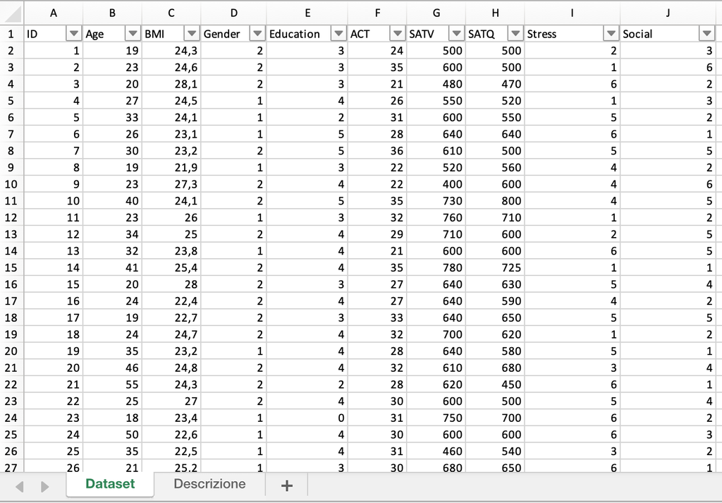

The dataset in Excel

We save them in CSV format and import with read.csv in R.

```r
data<-read.csv("test.csv",sep=";",header=T,dec=",")
head(data) #the first 6 rows
```

```
##   ID Age  BMI Gender Education ACT SATV SATQ Stress Social
## 1  1  19 24.3      2         3  24  500  500      2      3
## 2  2  23 24.6      2         3  35  600  500      1      6
## 3  3  20 28.1      2         3  21  480  470      6      2
## 4  4  27 24.5      1         4  26  550  520      1      3
## 5  5  33 24.1      1         2  31  600  550      5      2
## 6  6  26 23.1      1         5  28  640  640      6      1
```

```r
names(data)
```

```
##  [1] "ID"        "Age"       "BMI"       "Gender"    "Education" "ACT"
##  [7] "SATV"      "SATQ"      "Stress"    "Social"
```

# Reproducible Statistical Analysis with R-Markdown

## Why use R-Markdown

The use of RStudio with R-Markdown provides the basis to edit text and executable R code is the same text file.  
R-Markdown permits to  
- create HTML, PDF, or MS Word output;  
- use beamer, ioslides, and slidy presentations  
- manage tables, figures and bibliographies  
- create a customizable envirment.

There are a lot of sites. More about R Markdown:

- rmarkdown.rstudio.com
- [online reference guide](https://www.rstudio.com/wp-content/uploads/2015/03/rmarkdown-reference.pdf)

## Create an RStudio project

## Create an Rmd report

From RStudio, create a new R Markdown file

[figure not shown]

rmarkdown.rstudio.com

Select HTML output (for now). We can change it later.

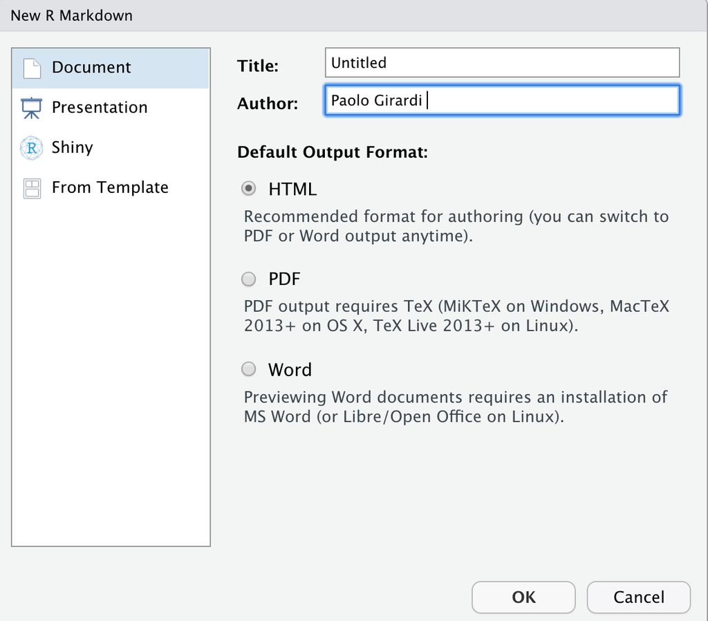

rmarkdown.rstudio.com

An untitled R Markdown file is created with some default text and R code.

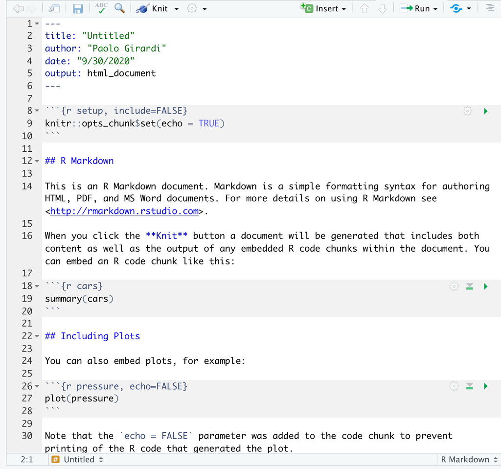

rmarkdown.rstudio.com

*File* -> *Save As* to the project directory with an Rmd suffix, for example, `test-report.Rmd`.

Click `Knit HTML` to render the document in HTML.

The report appears in your RStudio viewer (or can be opened in other HTML viewer).